# Lesson 3

### What to Do First?

Notes: Read data

### Pseudo-Facebook User Data

Notes: fb seudo user data

```r
getwd()
```

```
## [1] "/home/williamn/Repository/dataAnalysis/udacity/data analysis R"
```

```r
setwd('/home/williamn/Repository/dataAnalysis/udacity/data\ analysis\ R')
list.files()
```

```
## [1] "dAUdacity.R"            "demystifying.R"
## [3] "demystifyingR2_v3.html" "demystifyingR2_v3.Rmd"
## [5] "lesson3_student_files"  "lesson3_student.rmd"
## [7] "pseudo_facebook.tsv"    "reddit.csv"
```

```r
pf<- read.csv('pseudo_facebook.tsv', sep = '\t')
```

### Histogram of Users’ Birthdays

Notes: histogram of the users’ birthdays

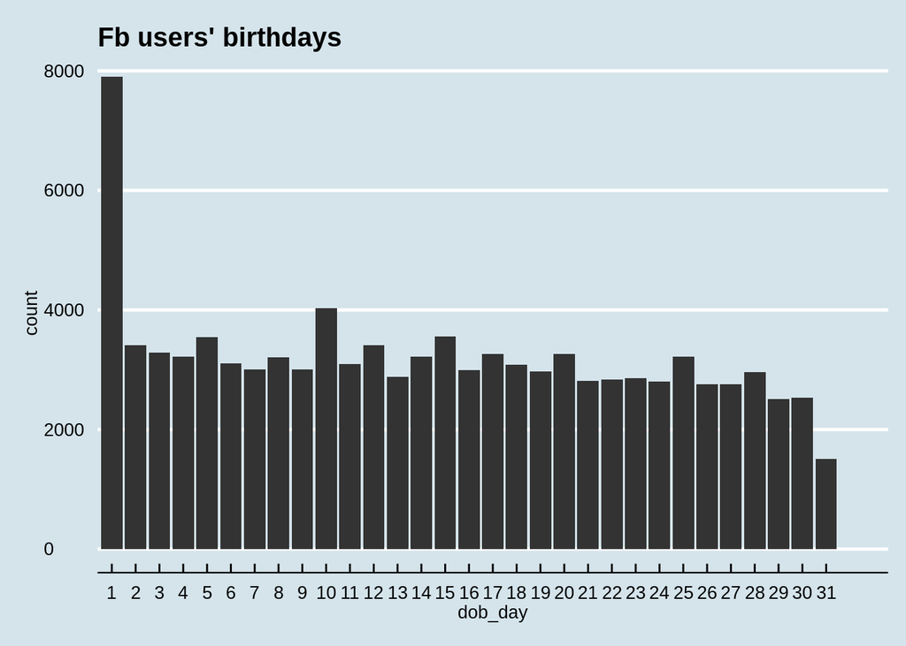

```r
# install.packages('ggplot2')
library(ggplot2)
library(ggthemes)

qplot(x = dob_day, data = pf) +
    scale_x_discrete(breaks = 1:31) +
    theme_economist() +
    scale_colour_economist() +
    ggtitle("Fb users' birthdays")
```

#### What are some things that you notice about this histogram?

Response: Day one has the highest birthdays in a month

### Moira’s Investigation

Notes: She wanted to know whether the perceived audience matches up the reality

### Estimating Your Audience Size

Notes: Audience on fb

#### Think about a time when you posted a specific message or shared a photo on Facebook. What was it?

Response: My last profile picture

#### How many of your friends do you think saw that post?

Response: 40

#### Think about what percent of your friends on Facebook see any posts or comments that you make in a month. What percent do you think that is?

Response: 10

### Perceived Audience Size

Notes: 10

### Faceting

Notes:

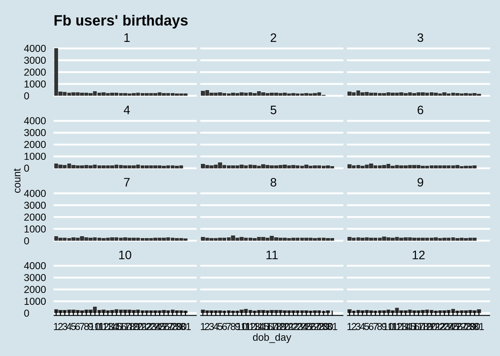

```r
qplot(x = dob_day, data = pf) +
    scale_x_discrete(breaks = 1:31) +
    facet_wrap(~dob_month, ncol = 3) +
    theme_economist() +
    scale_colour_economist() +
    ggtitle("Fb users' birthdays")
```

#### Let’s take another look at our plot. What stands out to you here?

Response: January 1st has the highest rate of birthdays of the year

### Be Skeptical - Outliers and Anomalies

Notes: January 1st

### Friend Count

Notes: Number of friends

#### What code would you enter to create a histogram of friend counts?

```r
names(pf)
```

```
##  [1] "userid"                "age"
##  [3] "dob_day"               "dob_year"
##  [5] "dob_month"             "gender"
##  [7] "tenure"                "friend_count"
##  [9] "friendships_initiated" "likes"
## [11] "likes_received"        "mobile_likes"
## [13] "mobile_likes_received" "www_likes"
## [15] "www_likes_received"
```

```
## stat_bin: binwidth defaulted to range/30. Use 'binwidth = x' to adjust this.
```

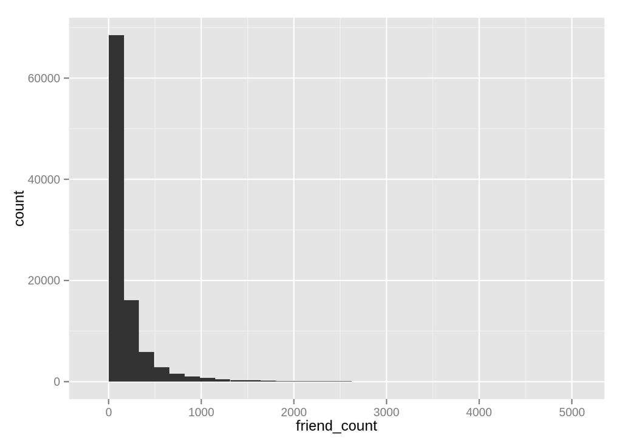

```r
qplot(x = friend_count, data = pf)
```

#### How is this plot similar to Moira’s first plot?

Response: The first bar is as big as Moira’s first plot

### Limiting the Axes

Notes: When you want to focus on a significant range

```
## stat_bin: binwidth defaulted to range/30. Use 'binwidth = x' to adjust this.
```

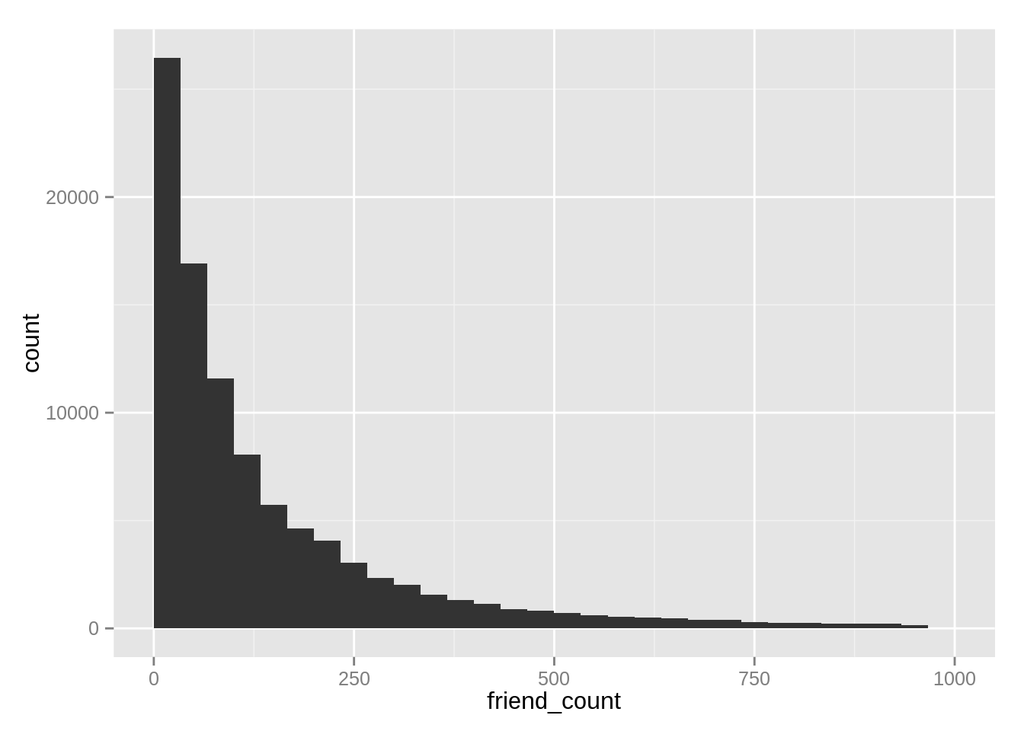

```r
qplot(x = friend_count, data = pf, xlim = c(0, 1000))
```

```
## stat_bin: binwidth defaulted to range/30. Use 'binwidth = x' to adjust this.
```

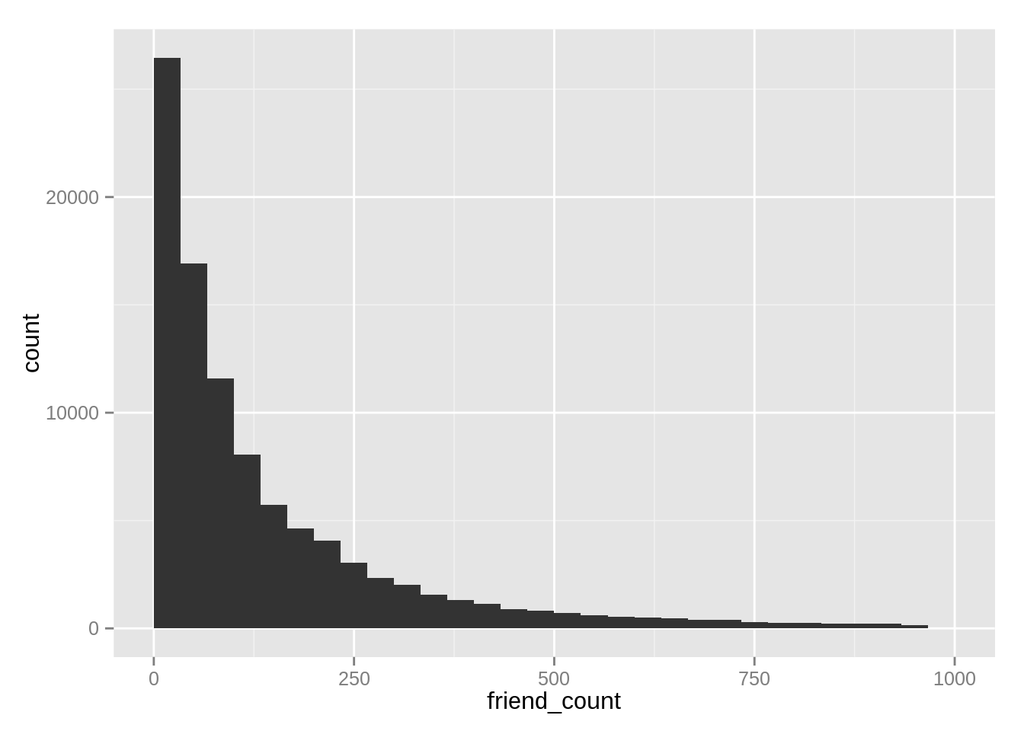

```r
qplot(x = friend_count, data = pf) +
    scale_x_continuous(limits = c(0, 1000))
```

### Exploring with Bin Width

Notes: Managing bin width allows to get a bether insight of the data

### Adjusting the Bin Width

Notes:

### Faceting Friend Count

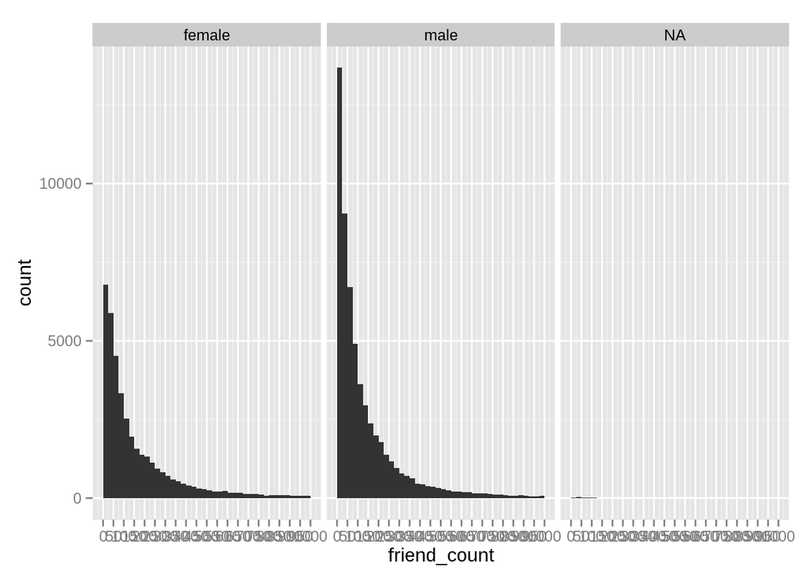

```r
# What code would you add to create a facet the histogram by gender?
# Add it to the code below.
qplot(x = friend_count, data = pf, binwidth = 25) +
  scale_x_continuous(limits = c(0, 1000),
                     breaks = seq(0, 1000, 50)) +
    facet_wrap(~gender)
```

### Omitting NA Values

Notes: NA ~ Not applicable

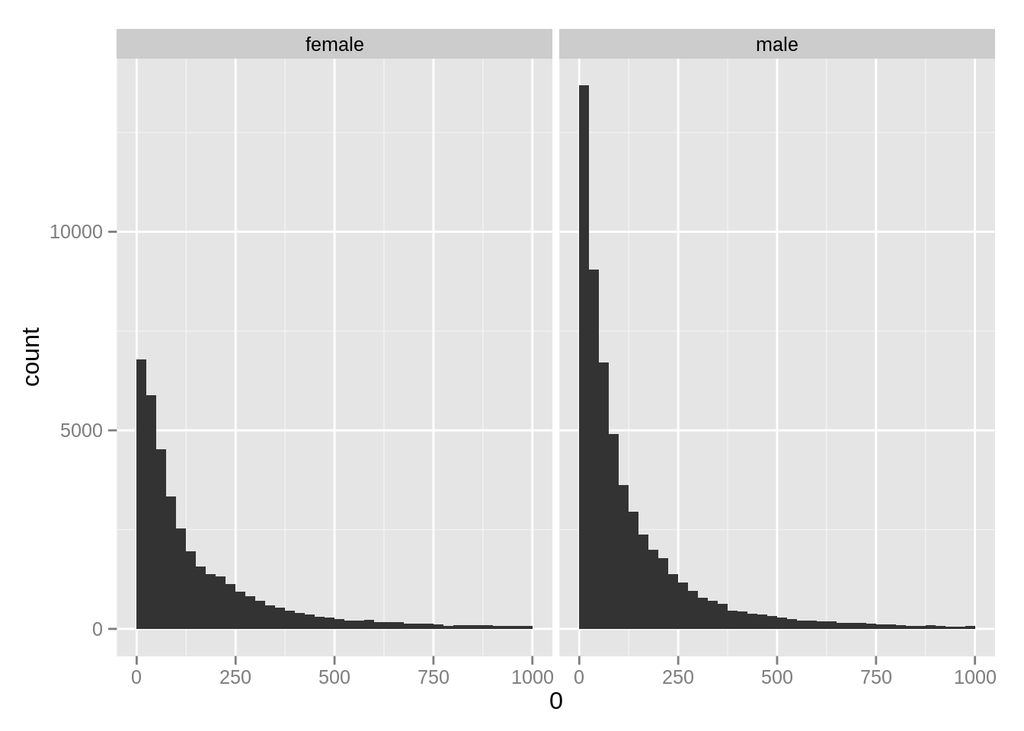

```r
qplot(x = friend_count, data = subset(pf, !is.na(gender)),
      xlim = c(0, 1000), xlab = seq(0, 1000, 50), binwidth = 25) +
    facet_wrap(~gender)
```

### Statistics ‘by’ Gender

Notes:

```r
table(pf$gender)
```

```
##
## female   male
##  40254  58574
```

```r
by(pf$friend_count, pf$gender, summary)
```

```
## pf$gender: female
##    Min. 1st Qu.  Median    Mean 3rd Qu.    Max.
##       0      37      96     242     244    4923
## --------------------------------------------------------
## pf$gender: male
##    Min. 1st Qu.  Median    Mean 3rd Qu.    Max.
##       0      27      74     165     182    4917
```

#### Who on average has more friends: men or women?

Response: women

#### What’s the difference between the median friend count for women and men?

Response: 22

#### Why would the median be a better measure than the mean?

Response: because it represent better the average of friends than the mean

### Tenure

Notes: The number of days that somenone has been using fb

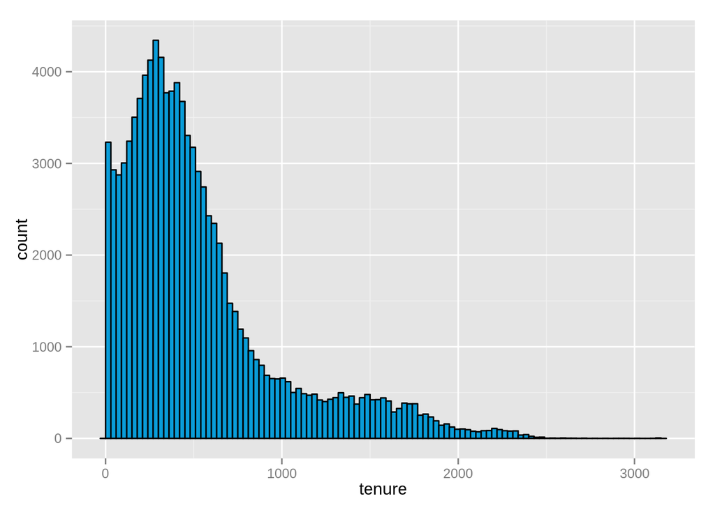

```r
qplot(x = tenure, data = pf, binwidth = 30,
      color = I('black'), fill = I('#099DD9'))
```

#### How would you create a histogram of tenure by year?

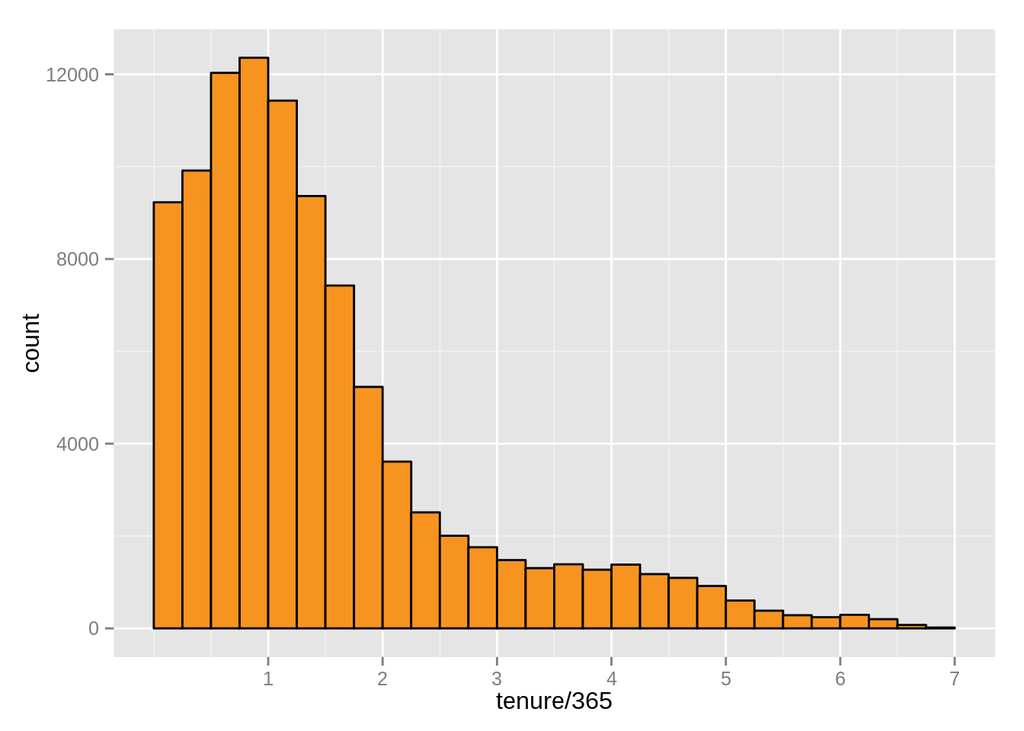

```r
qplot(x = tenure/365, data = pf, binwidth = 0.25,
      color = I('black'), fill = I('#F79420')) +
    scale_x_continuous(limits = c(0, 7), breaks = seq(1, 7, 1))
```

### Labeling Plots

Notes: Give us a better description of the plot

```
## stat_bin: binwidth defaulted to range/30. Use 'binwidth = x' to adjust this.
```

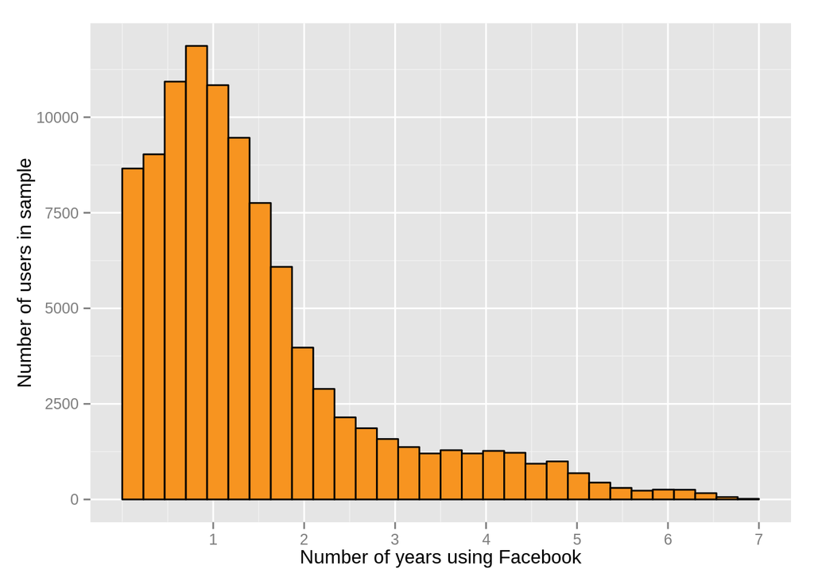

```r
qplot(x = tenure/365, data = pf,
      xlab = 'Number of years using Facebook',
      ylab = 'Number of users in sample',
      color = I('black'), fill = I('#F79420')) +
    scale_x_continuous(limits = c(0, 7), breaks = seq(1, 7, 1))
```

### User Ages

Notes:

```r
summary(pf$age)
```

```
##    Min. 1st Qu.  Median    Mean 3rd Qu.    Max.
##   13.00   20.00   28.00   37.28   50.00  113.00
```

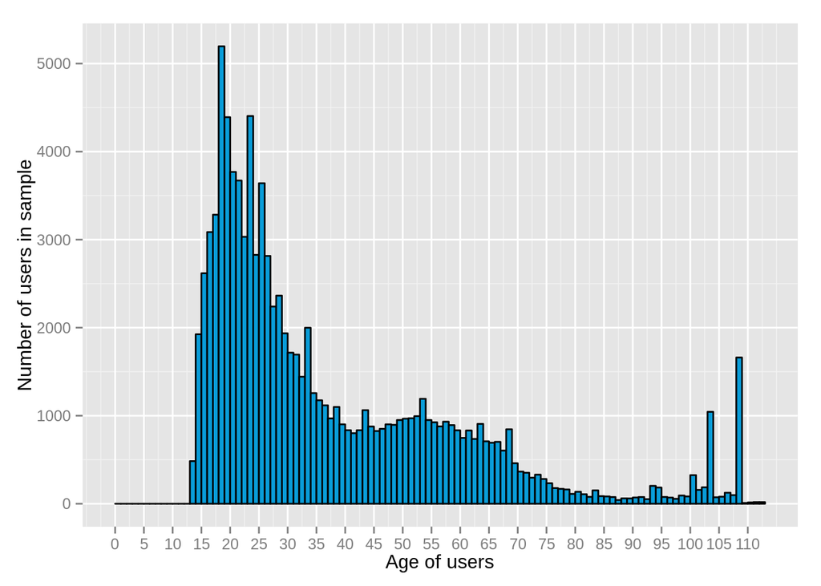

```r
qplot(x = age, data = pf, binwidth = 1,
      xlab = 'Age of users',
      ylab = 'Number of users in sample',
      color = I('black'), fill = I('#099DD9')) +
    scale_x_continuous(limits = c(0, 113), breaks = seq(0, 113, 5))
```

#### What do you notice?

Response: Most of the users are between 15 to 30 years old

### The Spread of Memes

Notes: The frecuency of appearance of memes

### Lada’s Money Bag Meme

Notes: october 2010

### Transforming Data

Notes: If the data doesn’t have a normal distribution

```r
# install.packages('gridExtra')
library('gridExtra')
```

```r
# Defining individual plots
summary(pf$friend_count)
```

```
##    Min. 1st Qu.  Median    Mean 3rd Qu.    Max.
##     0.0    31.0    82.0   196.4   206.0  4923.0
```

```
## stat_bin: binwidth defaulted to range/30. Use 'binwidth = x' to adjust this.
## stat_bin: binwidth defaulted to range/30. Use 'binwidth = x' to adjust this.
## stat_bin: binwidth defaulted to range/30. Use 'binwidth = x' to adjust this.
```

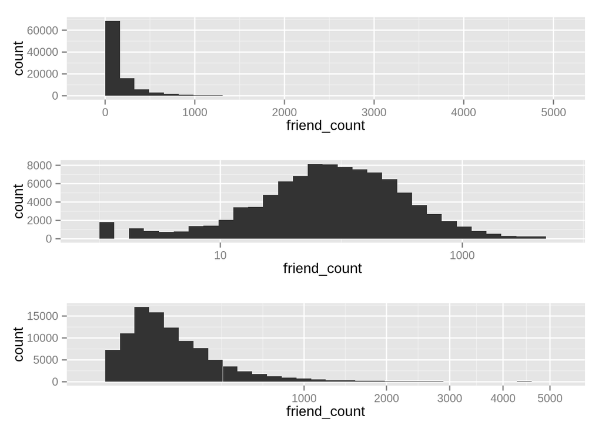

```r
p1<- qplot(x = friend_count, data = pf)
p2<- p1 + scale_x_log10()
p3<- p1 + scale_x_sqrt()

# Another way
p1<- qplot(x = friend_count, data = pf)
p2<- qplot(x = log10(friend_count + 1), data = pf)
p3<- qplot(x = sqrt(friend_count), data = pf)

# Alternate solution
p1<- ggplot(aes(x = friend_count), data = pf) +
    geom_histogram()
p2<- p1 + scale_x_log10()
p3<- p1 + scale_x_sqrt()

# arrange plots in grid
grid.arrange(p1, p2, p3, ncol = 1)
```

### Add a Scaling Layer

Notes:

```
## stat_bin: binwidth defaulted to range/30. Use 'binwidth = x' to adjust this.
```

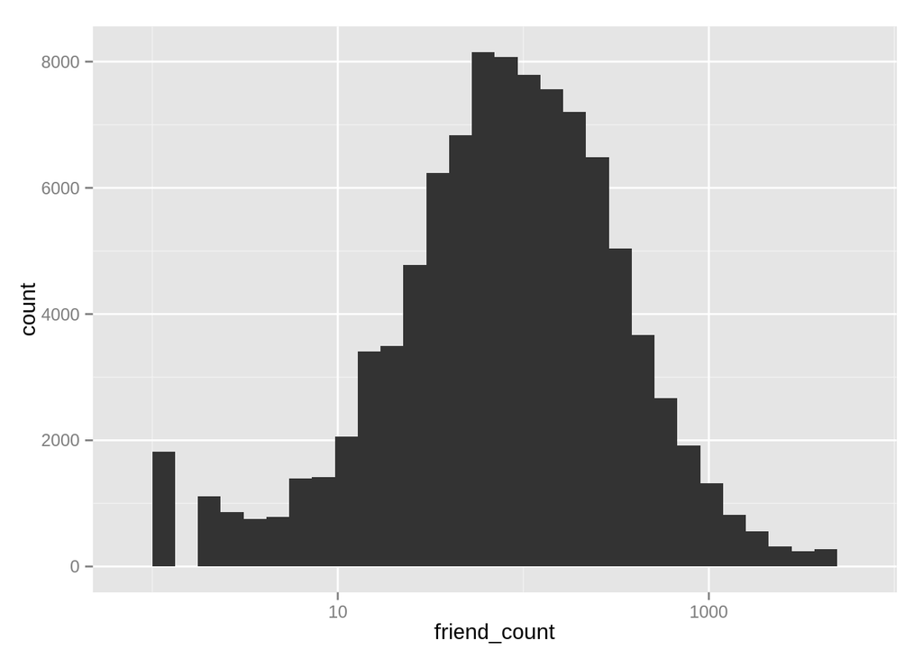

```r
ggplot(aes(x = friend_count), data = pf) +
    geom_histogram() +
    scale_x_log10()
```

### Frequency Polygons

```
## stat_bin: binwidth defaulted to range/30. Use 'binwidth = x' to adjust this.
```

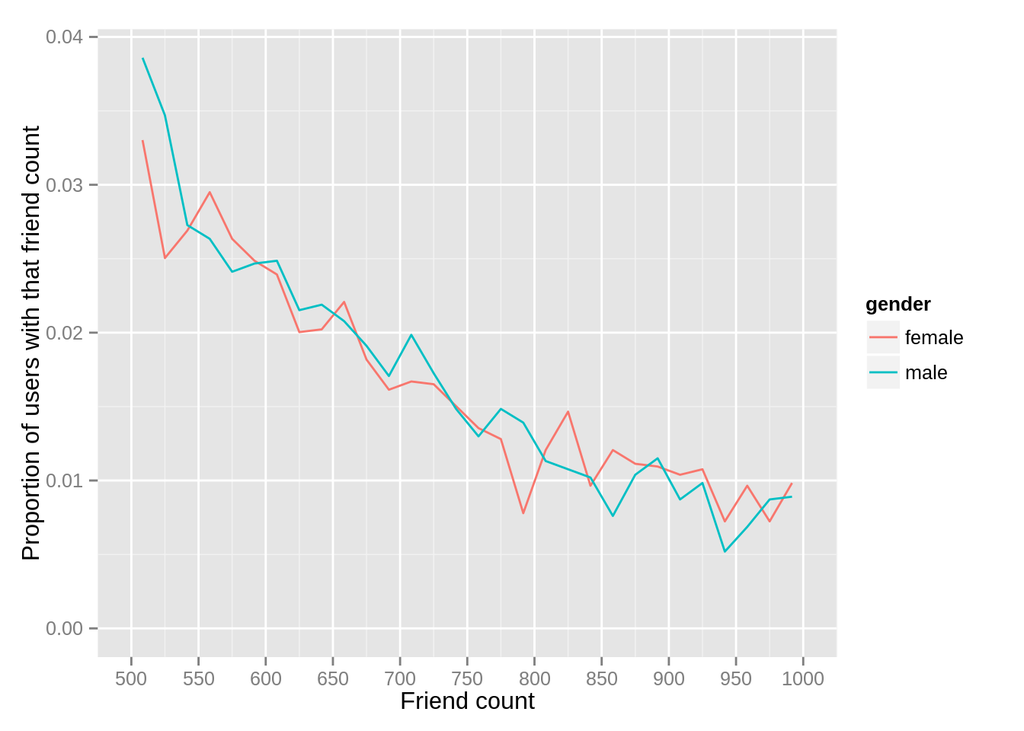

```r
qplot(x = friend_count, y = ..count../sum(..count..),
      data = subset(pf, !is.na(gender)),
      xlab = 'Friend count',
      ylab = 'Proportion of users with that friend count',
      geom = 'freqpoly', color = gender) +
    scale_x_continuous(lim = c(500, 1000), breaks = seq(500, 1000, 50))
```

### Likes on the Web

Notes: who has more likes males or females?

```r
summary(pf$www_likes)
```

```
##     Min.  1st Qu.   Median     Mean  3rd Qu.     Max.
##     0.00     0.00     0.00    49.96     7.00 14860.00
```

```
## stat_bin: binwidth defaulted to range/30. Use 'binwidth = x' to adjust this.
```

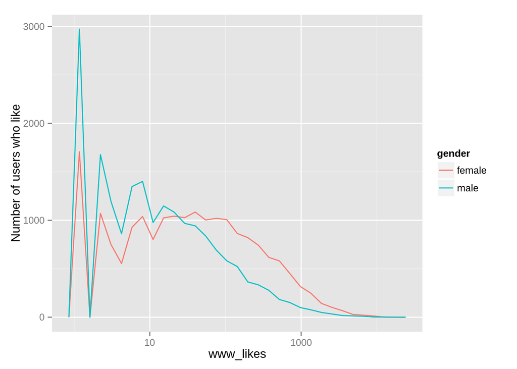

```r
qplot(x = www_likes,
      data = subset(pf, !is.na(gender)),
      xlab = 'www_likes',
      ylab = 'Number of users who like',
      geom = 'freqpoly', color = gender) +
    scale_x_log10()
```

```r
# Statistics about likes by gender
tail(pf)
```

```
##        userid age dob_day dob_year dob_month gender tenure friend_count
## 98998 1458985  28      14     1985        12 female    290         2218
## 98999 1268299  68       4     1945         4 female    541         2118
## 99000 1256153  18      12     1995         3 female     21         1968
## 99001 1195943  15      10     1998         5 female    111         2002
## 99002 1468023  23      11     1990         4 female    416         2560
## 99003 1397896  39      15     1974         5 female    397         2049
##       friendships_initiated likes likes_received mobile_likes
## 98998                  1618  4626          10268         4290
## 98999                   341  3996          18089         3505
## 99000                  1720  4401          13412         4399
## 99001                  1524 11959          12554        11959
## 99002                   185  4506           6516         4506
## 99003                   768  9410          12443         9410
##       mobile_likes_received www_likes www_likes_received
## 98998                  4250       336               6018
## 98999                 11887       491               6202
## 99000                 10592         2               2820
## 99001                 11462         0               1092
## 99002                  5760         0                756
## 99003                  9530         0               2913
```

```r
# What's the www_like count for males?
by(pf$www_likes, pf$gender, summary)
```

```
## pf$gender: female
##     Min.  1st Qu.   Median     Mean  3rd Qu.     Max.
##     0.00     0.00     0.00    87.14    25.00 14860.00
## --------------------------------------------------------
## pf$gender: male
##     Min.  1st Qu.   Median     Mean  3rd Qu.     Max.
##     0.00     0.00     0.00    24.42     2.00 12900.00
```

```r
maleLikes<- pf[pf$gender=='male',]
maleTotalLikes<- sum(maleLikes$www_likes, na.rm = TRUE)

# Alternate solution
by(pf$www_likes, pf$gender, sum)
```

```
## pf$gender: female
## [1] 3507665
## --------------------------------------------------------
## pf$gender: male
## [1] 1430175
```

#### What’s the www_like count for males?

Response: 1430175

#### Which gender has more www_likes?

Response: females

### Box Plots

Notes: Summary information about the data in just one box

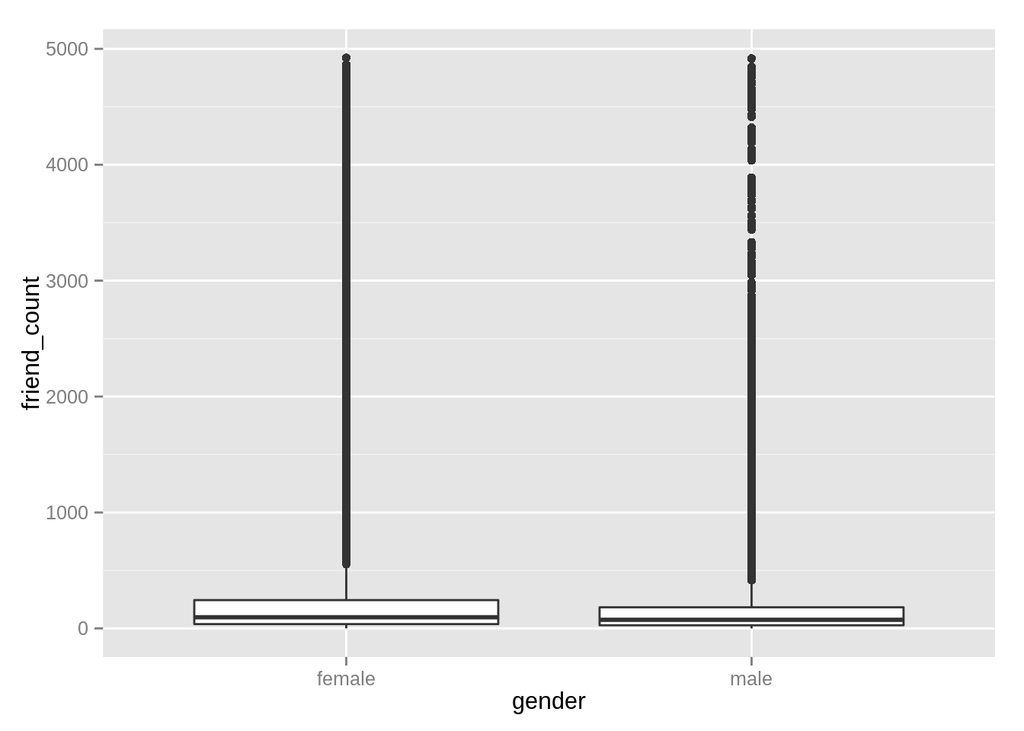

```r
qplot(x = gender, y = friend_count, data = subset(pf, !is.na(gender)),
      geom = 'boxplot')
```

#### Adjust the code to focus on users who have friend counts between 0 and 1000.

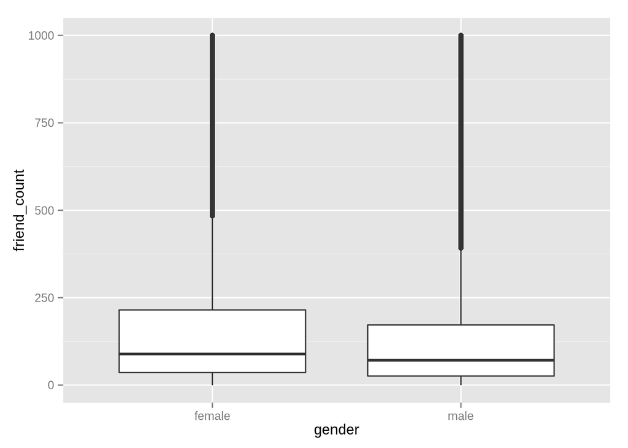

```r
# The data outside the range is ignored
qplot(x = gender, y = friend_count, data = subset(pf, !is.na(gender)),
      geom = 'boxplot') +
    scale_y_continuous(lim = c(0, 1000))
```

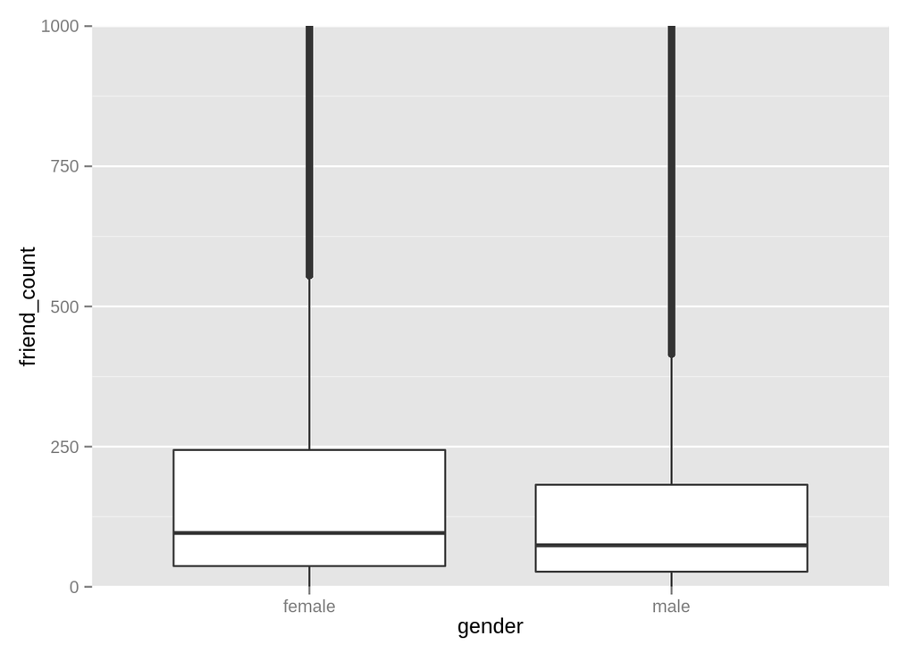

```r
# Alternate code: coord_cartesian sets the viewing area of the data
qplot(x = gender, y = friend_count, data = subset(pf, !is.na(gender)),
      geom = 'boxplot') +
    coord_cartesian(ylim = c(0, 1000))
```

### Box Plots, Quartiles, and Friendships

Notes:

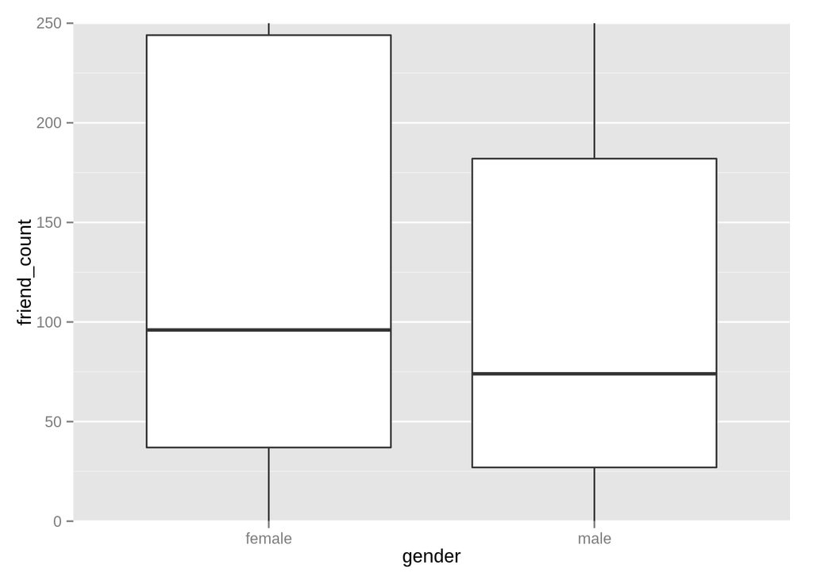

```r
qplot(x = gender, y = friend_count, data = subset(pf, !is.na(gender)),
      geom = 'boxplot') +
    coord_cartesian(ylim = c(0, 250))
```

```r
by(pf$friend_count, pf$gender, summary)
```

```
## pf$gender: female
##    Min. 1st Qu.  Median    Mean 3rd Qu.    Max.
##       0      37      96     242     244    4923
## --------------------------------------------------------
## pf$gender: male
##    Min. 1st Qu.  Median    Mean 3rd Qu.    Max.
##       0      27      74     165     182    4917
```

#### On average, who initiated more friendships in our sample: men or women?

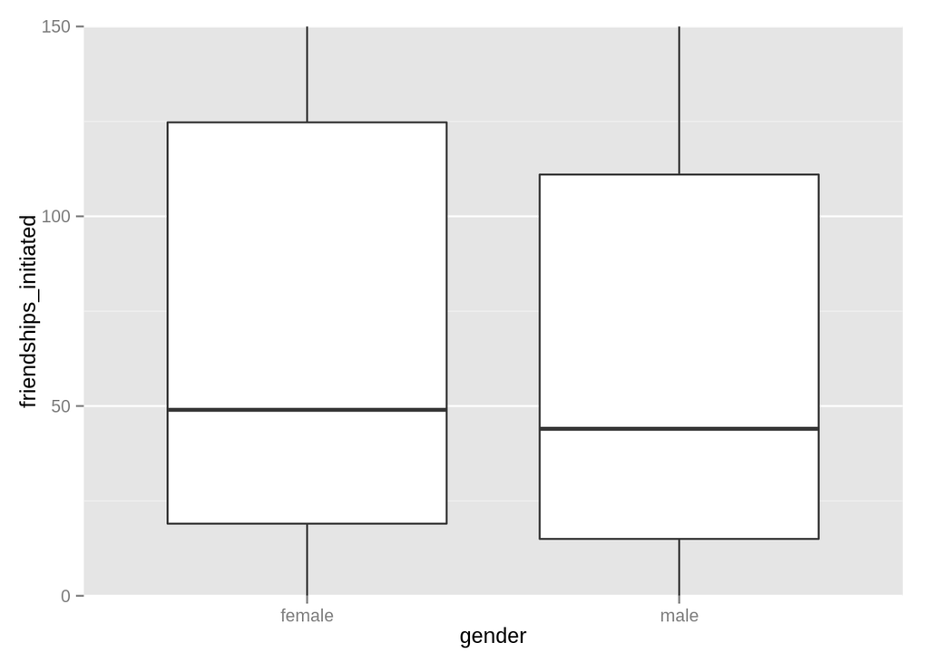

```r
qplot(x = gender, y = friendships_initiated, data = subset(pf, !is.na(gender)),
      geom = 'boxplot') +
    coord_cartesian(ylim = c(0, 150))
```

```r
by(pf$friendships_initiated, pf$gender, summary)
```

```
## pf$gender: female
##    Min. 1st Qu.  Median    Mean 3rd Qu.    Max.
##     0.0    19.0    49.0   113.9   124.8  3654.0
## --------------------------------------------------------
## pf$gender: male
##    Min. 1st Qu.  Median    Mean 3rd Qu.    Max.
##     0.0    15.0    44.0   103.1   111.0  4144.0
```

### Getting Logical

Notes: If we want to know whether someone has ever used a specific feature instead of the number of times that has used it.

```r
summary(pf$mobile_likes)
```

```
##    Min. 1st Qu.  Median    Mean 3rd Qu.    Max.
##     0.0     0.0     4.0   106.1    46.0 25110.0
```

```r
summary(pf$mobile_likes > 0)
```

```
##    Mode   FALSE    TRUE    NA's
## logical   35056   63947       0
```

```r
pf$mobile_check_in<- NA
pf$mobile_check_in<- ifelse(pf$mobile_likes > 0, 1, 0)
pf$mobile_check_in<- factor(pf$mobile_check_in)
summary(pf$mobile_check_in)
```

```
##     0     1
## 35056 63947
```

```r
percentage<- 63947/99003

# Using code
sum(pf$mobile_check_in == 1)/length(pf$mobile_check_in)
```

```
## [1] 0.6459097
```

Response:

### Analyzing One Variable

Reflection: I’ve learned a lot

Click **KnitHTML** to see all of your hard work and to have an html page of this lesson, your answers, and your notes!